# DV_RProject2

Ronly Leung, Karen Lee

October 1, 2015

```r
require("jsonlite")
require("RCurl")
require(extrafont)
require(ggplot2)
require(tidyr)
require(dplyr)
```

## Procedure for getting our csv data onto Oracle.

#### 1. Require packages.

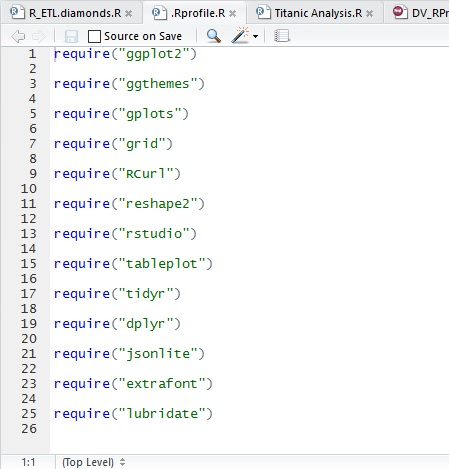

#### 2. Modify R_ETL.R: set working directory and file path, read our csv, use str() to determine which variables are continuous, and change measures accordingly.

[figure not shown]

#### 3. Run the code to get the SQL CREATE TABLE command.

#### 4. Use the command to create a table in SQL Developer to create a new table.

[figure not shown]

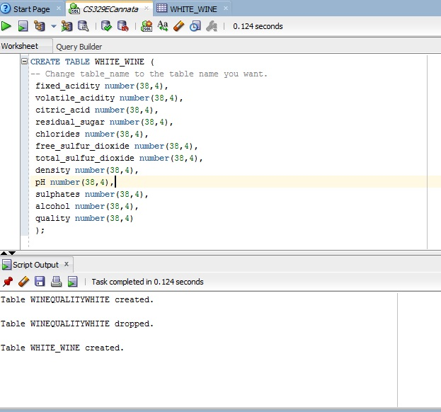

#### 5. Open the table, click “Actions,” and “Import Data…”

[figure not shown]

#### 6. Follow through the data import wizard (Match by Position)

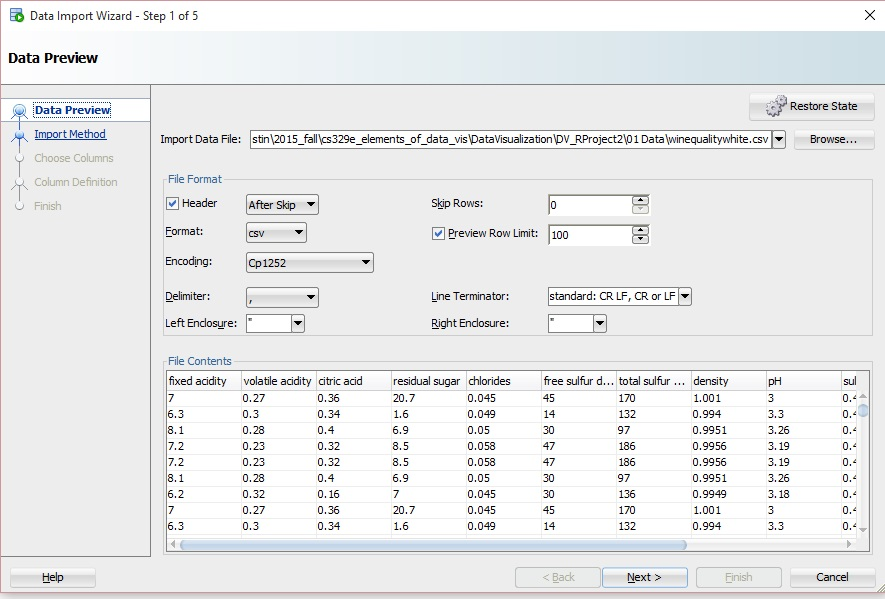

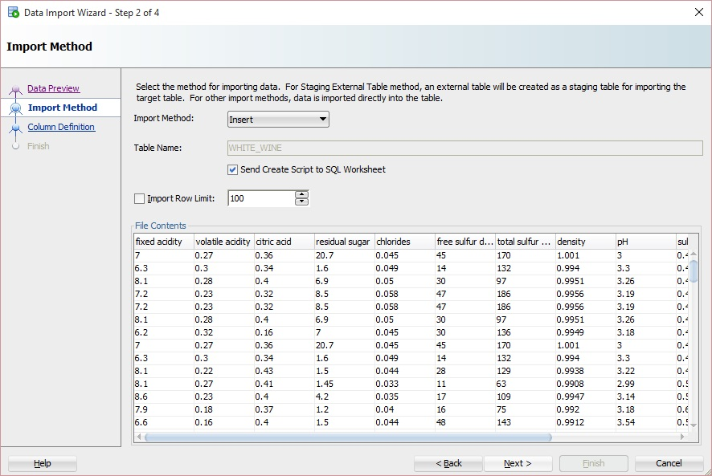

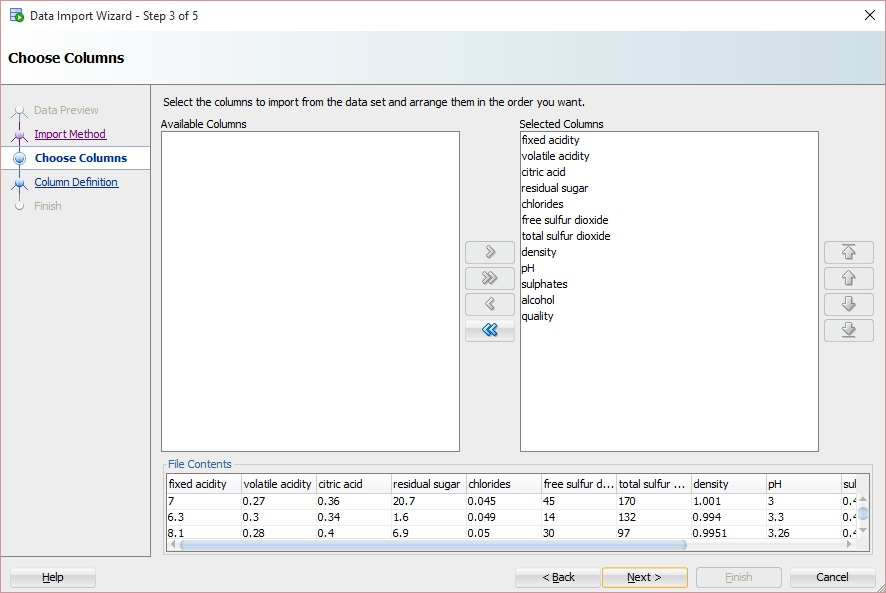

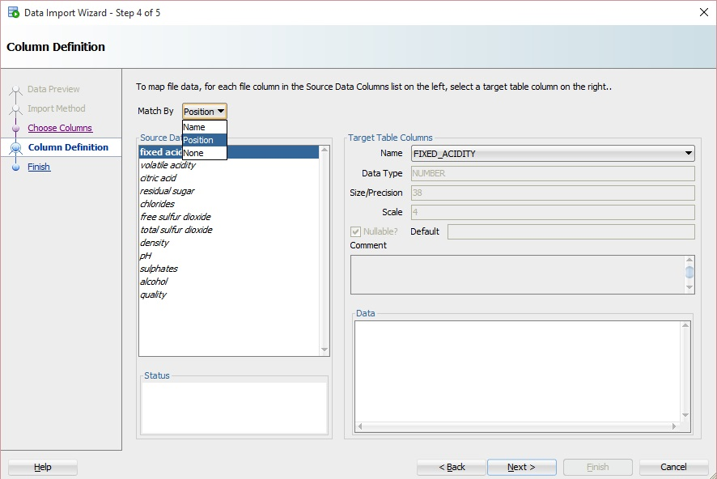

#### 7. All data from the csv file data should now be entered into the SQL table you created.

[figure not shown]

### Data Frame (Red and White Wine)

```r
source("../01 Data/redwhite.R", echo = TRUE)
```

```
##
## > require("jsonlite")
##
## > require("RCurl")
##
## > require(extrafont)
##
## > require(ggplot2)
##
## > redwhite <- data.frame(fromJSON(getURL(URLencode("129.152.144.84:5001/rest/native/?query=\"select * from red_white_wine\""),
## +     httpheader = c(D .... [TRUNCATED]
##
## > head(redwhite)
##   FIXED_ACIDITY VOLATILE_ACIDITY CITRIC_ACID RESIDUAL_SUGAR CHLORIDES
## 1           6.7             0.24        0.41            8.7     0.036
## 2           6.8             0.28        0.17           13.9     0.047
## 3           6.4             0.16        0.22            1.4     0.040
## 4           6.3             0.26        0.24            7.2     0.039
## 5           7.7             0.22        0.42            1.9     0.052
## 6           6.5             0.18        0.31            1.7     0.044
##   FREE_SULFUR_DIOXIDE TOTAL_SULFUR_DIOXIDE DENSITY   PH SULPHATES ALCOHOL
## 1                  29                  148  0.9952 3.22      0.62     9.9
## 2                  49                  162  0.9983 3.21      0.51     9.0
## 3                  41                  149  0.9933 3.49      0.58    10.0
## 4                  38                  172  0.9958 3.49      0.64     9.7
## 5                  10                   87  0.9922 3.30      0.49    11.8
## 6                  30                  127  0.9928 3.49      0.50    10.2
##   QUALITY COLOR
## 1       6 white
## 2       6 white
## 3       6 white
## 4       6 white
## 5       6 white
## 6       7 white
##
## > summary(redwhite)
##  FIXED_ACIDITY    VOLATILE_ACIDITY  CITRIC_ACID     RESIDUAL_SUGAR
##  Min.   : 3.800   Min.   :0.0800   Min.   :0.0000   Min.   : 0.600
##  1st Qu.: 6.400   1st Qu.:0.2300   1st Qu.:0.2500   1st Qu.: 1.800
##  Median : 7.000   Median :0.2900   Median :0.3100   Median : 3.000
```

[output cut: 9 more lines]

```
##  Max.   :0.61100   Max.   :289.00      Max.   :440.0
##     DENSITY             PH          SULPHATES         ALCOHOL
##  Min.   :0.9871   Min.   :2.720   Min.   :0.2200   Min.   : 8.00
##  1st Qu.:0.9923   1st Qu.:3.110   1st Qu.:0.4300   1st Qu.: 9.50
##  Median :0.9949   Median :3.210   Median :0.5100   Median :10.30
##  Mean   :0.9947   Mean   :3.219   Mean   :0.5313   Mean   :10.49
##  3rd Qu.:0.9970   3rd Qu.:3.320   3rd Qu.:0.6000   3rd Qu.:11.30
##  Max.   :1.0390   Max.   :4.010   Max.   :2.0000   Max.   :14.90
##     QUALITY        COLOR
##  Min.   :3.000   red  :1599
##  1st Qu.:5.000   white:4898
##  Median :6.000
##  Mean   :5.818
##  3rd Qu.:6.000
##  Max.   :9.000
```

#### Variables

Quality: Wine experts tasted and rated the quality of each wine sample on a scale from 0 (very bad) to 10 (very excellent).

```r
source("../03 Visualizations/whitequalitydistribution.R", echo = TRUE)
```

```
##
## > redwhite %>% select(QUALITY, COLOR) %>% filter(COLOR ==
## +     "white") %>% mutate(count = n()) %>% ggplot(aes(x = QUALITY,
## +     stat = "bin")) +  .... [TRUNCATED]
```

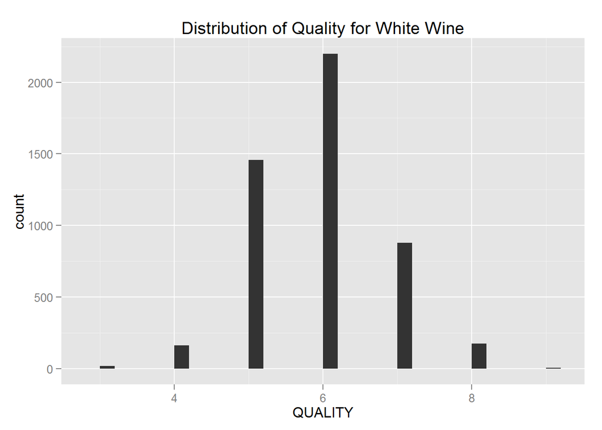

```r
source("../03 Visualizations/redqualitydistribution.R", echo = TRUE)
```

```
##
## > redwhite %>% select(QUALITY, COLOR) %>% filter(COLOR ==
## +     "red") %>% mutate(count = n()) %>% ggplot(aes(x = QUALITY,
## +     stat = "bin")) + ge .... [TRUNCATED]
```

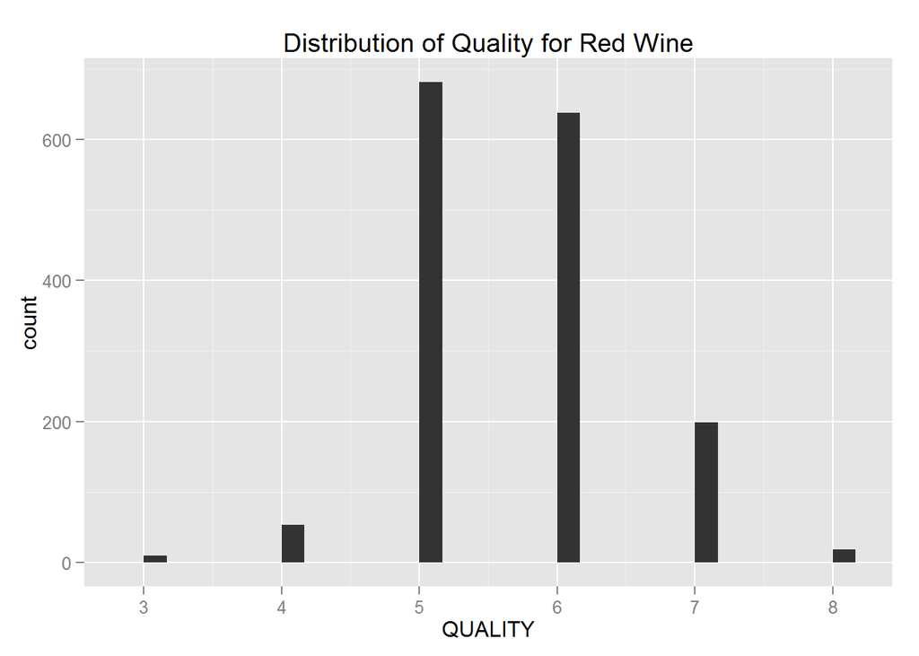

## Data Wrangling Visualizations

#### Visualization 1

This visualization shows that there’s a negative correlation between density and alcohol levels in white wine. Wine experts seem to prefer lower density and higher alcohol content, as they ranked those wines to be a 6-8 rather than a 3-5 on the scale of 1-10 (10 being the highest quality).

```r
source("../02 Data Wrangling/DW_1.R", echo = TRUE)
```

```
##
## > require("jsonlite")
##
## > require("RCurl")
##
## > require(tidyr)
##
## > require(dplyr)
##
## > require(ggplot2)
##
## > redwhite <- data.frame(fromJSON(getURL(URLencode("129.152.144.84:5001/rest/native/?query=\"select * from RED_WHITE_WINE\""),
## +     httpheader = c(D .... [TRUNCATED]
##
## > redwhite %>% select(ALCOHOL, DENSITY, QUALITY, COLOR) %>%
## +     filter(DENSITY <= 1.01 & COLOR == "white") %>% tbl_df
## Source: local data frame [4,895 x 4]
##
##    ALCOHOL DENSITY QUALITY  COLOR
##      (dbl)   (dbl)   (int) (fctr)
## 1      9.9  0.9952       6  white
## 2      9.0  0.9983       6  white
## 3     10.0  0.9933       6  white
## 4      9.7  0.9958       6  white
## 5     11.8  0.9922       6  white
## 6     10.2  0.9928       7  white
## 7      8.7  0.9976       5  white
## 8      9.6  0.9976       7  white
## 9     11.3  0.9916       7  white
## 10    12.1  0.9901       7  white
## ..     ...     ...     ...    ...
```

```r
source("../03 Visualizations/DV_1.R", echo = TRUE)
```

```
##
## > redwhite %>% select(ALCOHOL, DENSITY, QUALITY, COLOR) %>%
## +     filter(DENSITY <= 1.01 & COLOR == "white") %>% ggplot(aes(x = ALCOHOL,
## +     y = D .... [TRUNCATED]
```

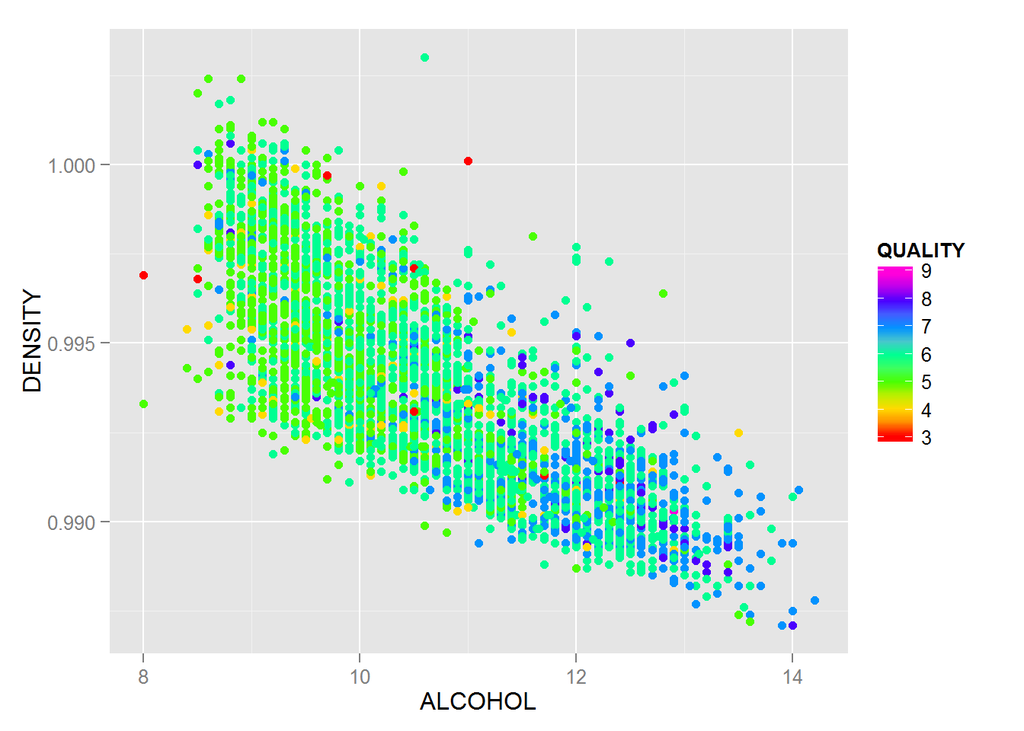

#### Visualization 2

```r
source("../02 Data Wrangling/DW_2.R", echo = TRUE)
```

```
##
## > require("jsonlite")
##
## > require("RCurl")
##
## > require(tidyr)
##
## > require(dplyr)
##
## > require(ggplot2)
##
## > redwhite <- data.frame(fromJSON(getURL(URLencode("129.152.144.84:5001/rest/native/?query=\"select * from RED_WHITE_WINE\""),
## +     httpheader = c(D .... [TRUNCATED]
##
## > redwhite %>% select(QUALITY, CITRIC_ACID, COLOR) %>%
## +     filter(CITRIC_ACID <= 1.2) %>% group_by(QUALITY, CITRIC_ACID) %>%
## +     tbl_df
## Source: local data frame [6,495 x 3]
##
##    QUALITY CITRIC_ACID  COLOR
##      (int)       (dbl) (fctr)
## 1        6        0.41  white
## 2        6        0.17  white
## 3        6        0.22  white
## 4        6        0.24  white
## 5        6        0.42  white
## 6        7        0.31  white
## 7        5        0.65  white
## 8        7        0.51  white
## 9        7        0.34  white
## 10       7        0.34  white
## ..     ...         ...    ...
```

```r
source("../03 Visualizations/DV_2.R", echo = TRUE)
```

```
##
## > redwhite %>% select(QUALITY, CITRIC_ACID, COLOR) %>%
## +     filter(CITRIC_ACID <= 1.2) %>% group_by(QUALITY, CITRIC_ACID) %>%
## +     ggplot(aes(x =  .... [TRUNCATED]
```

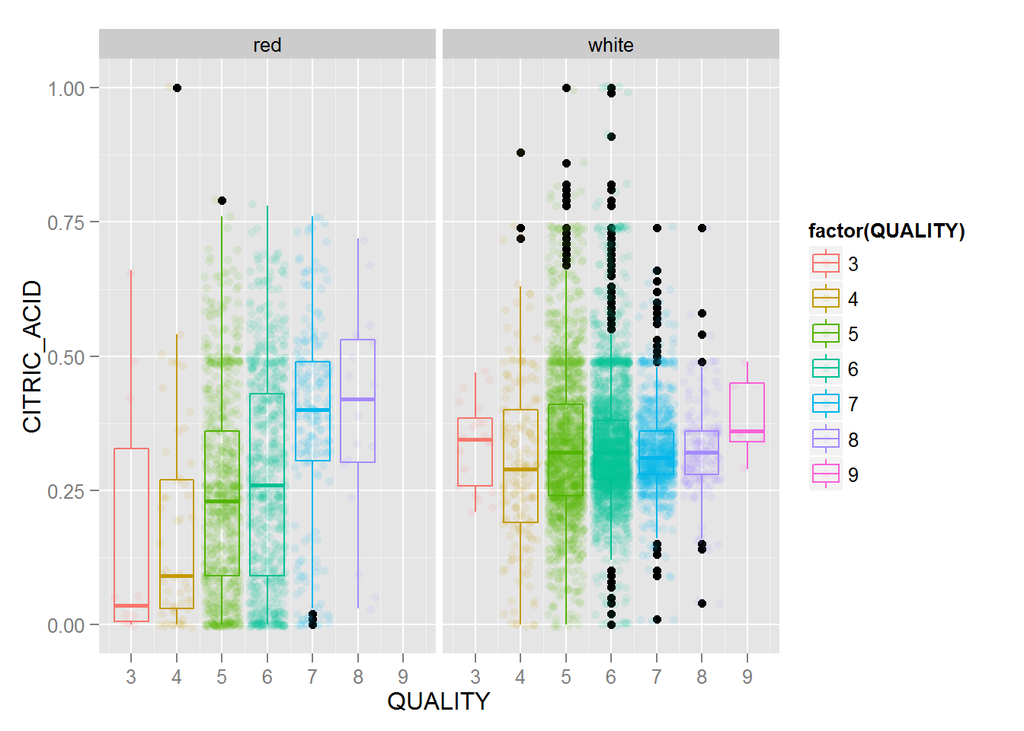

#### Visualition 3

These graphs show that white wine has a wider range of residual sugar levels compared to the residual sugar levels in red wine. There is a higher concentration of total sulfur dioxide in white wines. There is a stark contrast in choloride levels, as indicaded by the color of the points.

```r
source("../02 Data Wrangling/DW_3.R", echo = TRUE)
```

```
##
## > require("jsonlite")
##
## > require("RCurl")
##
## > require(tidyr)
##
## > require(dplyr)
##
## > require(ggplot2)
##
## > redwhite <- data.frame(fromJSON(getURL(URLencode("129.152.144.84:5001/rest/native/?query=\"select * from RED_WHITE_WINE\""),
## +     httpheader = c(D .... [TRUNCATED]
##
## > redwhite %>% select(TOTAL_SULFUR_DIOXIDE, RESIDUAL_SUGAR,
## +     CHLORIDES, COLOR) %>% filter(TOTAL_SULFUR_DIOXIDE < 150,
## +     RESIDUAL_SUGAR < 20 .... [TRUNCATED]
## Source: local data frame [4,573 x 4]
##
##    TOTAL_SULFUR_DIOXIDE RESIDUAL_SUGAR CHLORIDES  COLOR
##                   (dbl)          (dbl)     (dbl) (fctr)
## 1                   148            8.7     0.036  white
## 2                   149            1.4     0.040  white
## 3                    87            1.9     0.052  white
## 4                   127            1.7     0.044  white
## 5                    93            1.2     0.026  white
## 6                   118            1.6     0.028  white
## 7                   118            1.6     0.028  white
## 8                    93            1.2     0.026  white
## 9                   137            1.6     0.049  white
## 10                  144            4.2     0.047  white
## ..                  ...            ...       ...    ...
```

```r
source("../03 Visualizations/DV_3.R", echo = TRUE)
```

```
##
## > redwhite %>% filter(TOTAL_SULFUR_DIOXIDE < 150, RESIDUAL_SUGAR <
## +     20, CHLORIDES < 0.2) %>% ggplot(aes(x = TOTAL_SULFUR_DIOXIDE,
## +     y = RES .... [TRUNCATED]
```

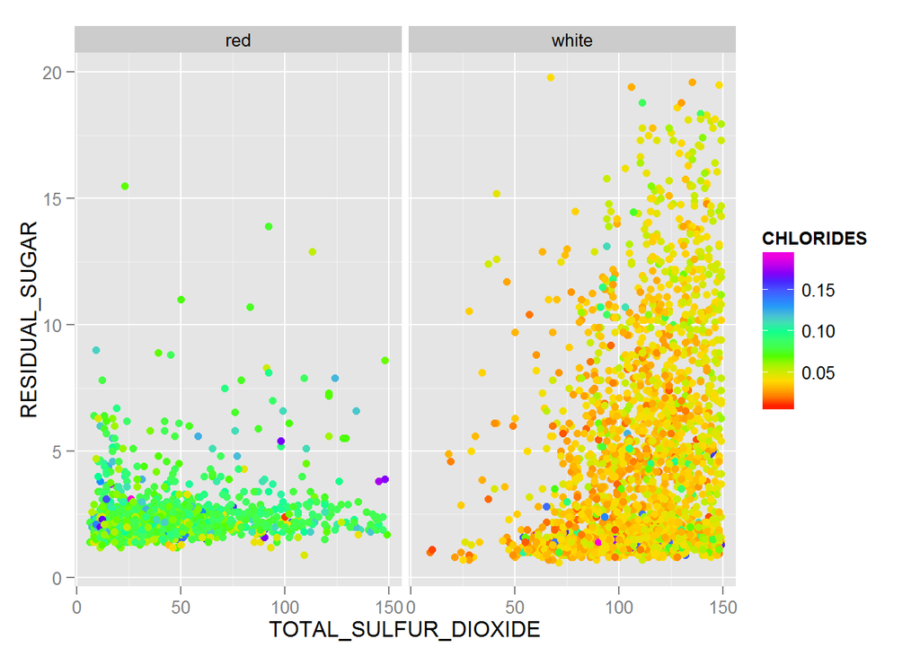

Citation:  
P. Cortez, A. Cerdeira, F. Almeida, T. Matos and J. Reis. Modeling wine preferences by data mining from physicochemical properties. In Decision Support Systems, Elsevier, 47(4):547-553. ISSN: 0167-9236.